# Do Spotify’s Daily Playlists Match My Taste? Analyzing Song Enjoyment and Skipping Patterns

Tony Chen

## Introduction — Why These Data?

Spotify recommends a daily playlist of songs, but do these songs actually match my music taste? I tracked 40 songs from my Spotify daily playlist to see how well the algorithm matched my preferences. Each time I listened to a recommended song, I recorded six details: the time I played it, the genre, whether I finished the song, how much I enjoyed it (rated 1 to 10), what I did next, and the time of day I listened.

This data helps me understand which genres I enjoy most, which ones I tend to skip, and whether the time of day affects my enjoyment. By exploring these patterns, I can see how well Spotify’s algorithm aligns with my listening habits.

> **Dataset:** 40 self-logged observations, 6 variables  
> **Period:** a few days  
> **Palette:** seven-step green (light ⇢ dark) used across every plot

## Average enjoyment by genre

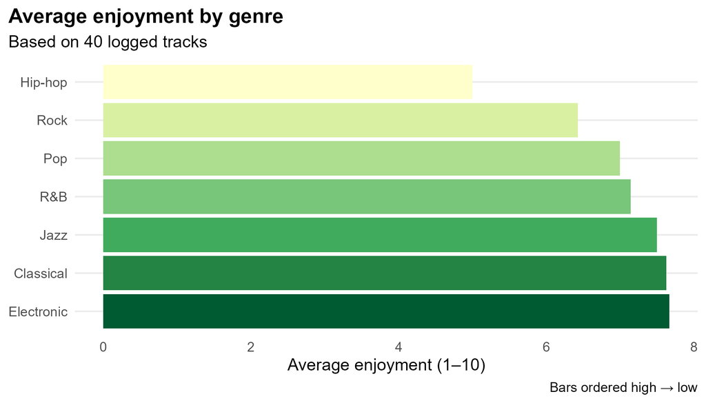

*Alt text:* A horizontal bar chart showing the average enjoyment of seven music genres on Spotify. The chart is sorted from lowest to highest enjoyment. Hip-hop has the lowest average score (around 4.8, light green), while Electronic has the highest (around 7.8, dark green).

**Key insight:** Among the seven genres, Electronic, Classical, and Jazz are the most enjoyed, with average scores above 7. In contrast, Hip-hop has the lowest average score, indicating it is the least enjoyed. The color gradient (light to dark green) helps visually reinforce the ranking, where darker shades mean higher enjoyment.

## Completion rate — Who gets skipped?

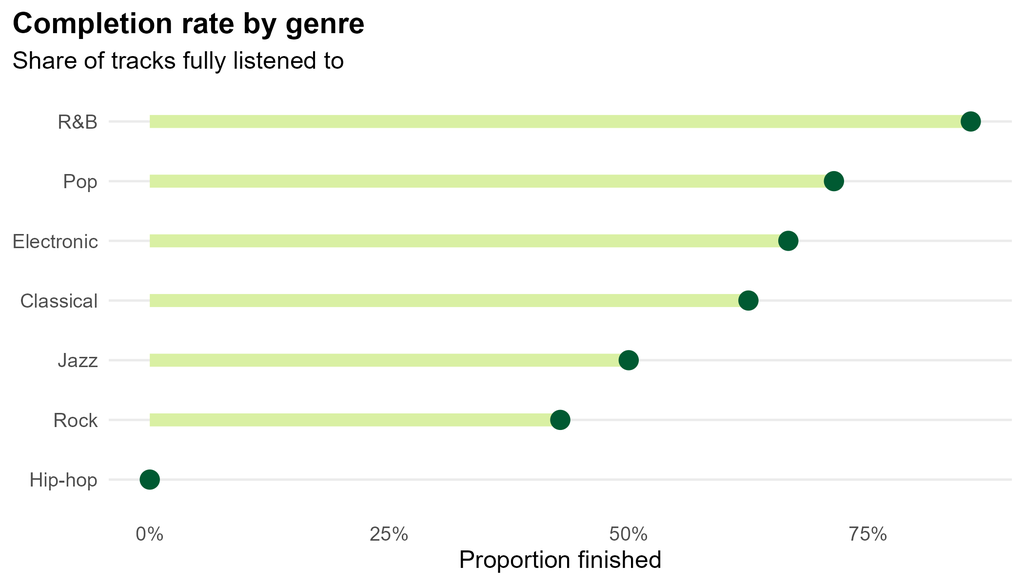

**Key insight:** R&B and Pop are most likely to be finished, suggesting these genres are well-aligned with my taste. In contrast, Hip-hop is consistently skipped, despite being included in the playlist. Completion rate does not always match enjoyment — Rock has a moderate enjoyment score but a low completion rate.

## Does time of day affect enjoyment?

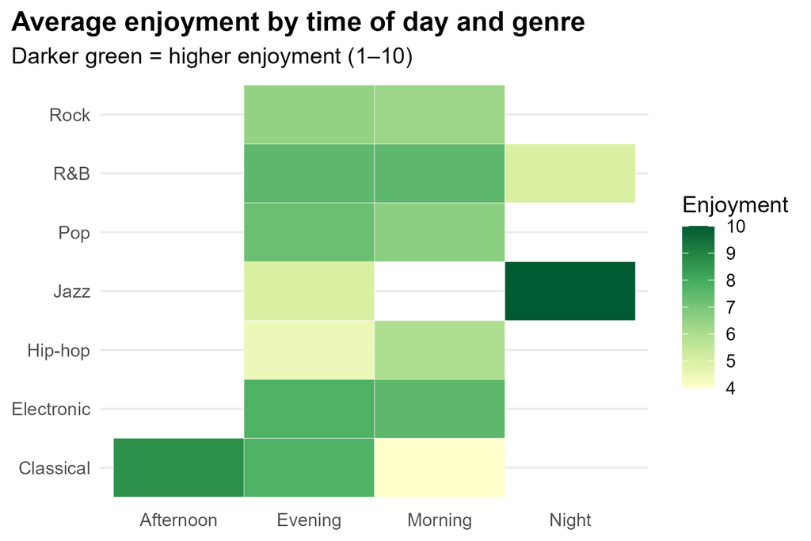

## Conclusion — Skip-Proof Strategies?

This mini-study shows that Spotify’s daily playlist sometimes aligns with my taste, but not always. It suggests the following insights:

- Align genre with context: Jazz works best at night, Classical in the afternoon.
- Completion does not always mean enjoyment: Rock has a moderate score but low completion.
- Hip-hop is both skipped and rated low, suggesting it should be reduced in recommendations.

Future improvements could include logging more songs, tracking the length of each track, and exploring whether familiarity with an artist affects enjoyment.